# Etape 3 : Data Cleaning

Etape très importante qui vise à analyser chaque colonne du dataset et de les modifier si besoin pour :

- Ajuster la colonne à prédire
- Corriger le format des colonnes
- Supprimer les colonnes avec trop de valeurs manquantes
- Corriger des valeurs manquantes ou erronées
- Faire du feature modeling

```python
import pandas as pd

train = pd.read_csv('train.csv')
test = pd.read_csv('test.csv')
data = pd.concat([train,test],sort=True)
data.reset_index(inplace=True)
data.head(5)
```

|  | index | 1stFlrSF | 2ndFlrSF | 3SsnPorch | Alley | BedroomAbvGr | BldgType | BsmtCond | BsmtExposure | BsmtFinSF1 | ... | SaleType | ScreenPorch | Street | TotRmsAbvGrd | TotalBsmtSF | Utilities | WoodDeckSF | YearBuilt | YearRemodAdd | YrSold |
| --- | --- | --- | --- | --- | --- | --- | --- | --- | --- | --- | --- | --- | --- | --- | --- | --- | --- | --- | --- | --- | --- |
| 0 | 0 | 856 | 854 | 0 | NaN | 3 | 1Fam | TA | No | 706.0 | ... | WD | 0 | Pave | 8 | 856.0 | AllPub | 0 | 2003 | 2003 | 2008 |
| 1 | 1 | 1262 | 0 | 0 | NaN | 3 | 1Fam | TA | Gd | 978.0 | ... | WD | 0 | Pave | 6 | 1262.0 | AllPub | 298 | 1976 | 1976 | 2007 |
| 2 | 2 | 920 | 866 | 0 | NaN | 3 | 1Fam | TA | Mn | 486.0 | ... | WD | 0 | Pave | 6 | 920.0 | AllPub | 0 | 2001 | 2002 | 2008 |
| 3 | 3 | 961 | 756 | 0 | NaN | 3 | 1Fam | Gd | No | 216.0 | ... | WD | 0 | Pave | 7 | 756.0 | AllPub | 0 | 1915 | 1970 | 2006 |
| 4 | 4 | 1145 | 1053 | 0 | NaN | 4 | 1Fam | TA | Av | 655.0 | ... | WD | 0 | Pave | 9 | 1145.0 | AllPub | 192 | 2000 | 2000 | 2008 |

5 rows × 82 columns

# Préparation de la donnée

**La valeur à prédire : le prix de la maison**

```python
data.columns
```

```
Index(['index', '1stFlrSF', '2ndFlrSF', '3SsnPorch', 'Alley', 'BedroomAbvGr',
       'BldgType', 'BsmtCond', 'BsmtExposure', 'BsmtFinSF1', 'BsmtFinSF2',
       'BsmtFinType1', 'BsmtFinType2', 'BsmtFullBath', 'BsmtHalfBath',
       'BsmtQual', 'BsmtUnfSF', 'CentralAir', 'Condition1', 'Condition2',
       'Electrical', 'EnclosedPorch', 'ExterCond', 'ExterQual', 'Exterior1st',
       'Exterior2nd', 'Fence', 'FireplaceQu', 'Fireplaces', 'Foundation',
       'FullBath', 'Functional', 'GarageArea', 'GarageCars', 'GarageCond',
       'GarageFinish', 'GarageQual', 'GarageType', 'GarageYrBlt', 'GrLivArea',
       'HalfBath', 'Heating', 'HeatingQC', 'HouseStyle', 'Id', 'KitchenAbvGr',
       'KitchenQual', 'LandContour', 'LandSlope', 'LotArea', 'LotConfig',
       'LotFrontage', 'LotShape', 'LowQualFinSF', 'MSSubClass', 'MSZoning',
       'MasVnrArea', 'MasVnrType', 'MiscFeature', 'MiscVal', 'MoSold',
       'Neighborhood', 'OpenPorchSF', 'OverallCond', 'OverallQual',
       'PavedDrive', 'PoolArea', 'PoolQC', 'RoofMatl', 'RoofStyle',
       'SaleCondition', 'SalePrice', 'SaleType', 'ScreenPorch', 'Street',
       'TotRmsAbvGrd', 'TotalBsmtSF', 'Utilities', 'WoodDeckSF', 'YearBuilt',
       'YearRemodAdd', 'YrSold'],
      dtype='object')
```

```python
print(data['SalePrice'].isnull().sum())
print(train['SalePrice'].isnull().sum())
```

```
1459
0
```

```python
train['SalePrice'].describe()
```

```
count      1460.000000
mean     180921.195890
std       79442.502883
min       34900.000000
25%      129975.000000
50%      163000.000000
75%      214000.000000
max      755000.000000
Name: SalePrice, dtype: float64
```

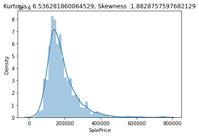

```
6.536281860064529
```

```python
import matplotlib.pyplot as plt
import seaborn as sns

sns.distplot(train['SalePrice'])
plt.title('Kurtosis : ' +str(train['SalePrice'].kurtosis())+ ', Skewness :' + str(train['SalePrice'].skew()))
plt.show()
print(train['SalePrice'].kurtosis())
```

**Les autres colonnes**  
Ont-elles le bon format ?

```python
data.drop(['SalePrice'],axis=1, inplace=True)
```

```python
data['1stFlrSF'].head(5)
```

```
0     856
1    1262
2     920
3     961
4    1145
Name: 1stFlrSF, dtype: int64
```

```python
list(data['1stFlrSF'].head(5))
```

```
[856, 1262, 920, 961, 1145]
```

```python
echantillonColonnes = []
for i in data.columns:
    listcolumn = str(list(data[i].head(5)))
    echantillonColonnes.append(listcolumn)
echantillonColonnes[0:5]
```

```
['[0, 1, 2, 3, 4]',
 '[856, 1262, 920, 961, 1145]',
 '[854, 0, 866, 756, 1053]',
 '[0, 0, 0, 0, 0]',
 '[nan, nan, nan, nan, nan]']
```

```python
list(data.dtypes[0:5])
```

```
[dtype('int64'), dtype('int64'), dtype('int64'), dtype('int64'), dtype('O')]
```

```python
d = {'colonne': list(data.columns), 'type': list(data.dtypes), 'Echantillon':echantillonColonnes}
colonnesTypes = pd.DataFrame(data=d)

pd.options.display.max_rows = 81
colonnesTypes
```

|  | colonne | type | Echantillon |
| --- | --- | --- | --- |
| 0 | index | int64 | [0, 1, 2, 3, 4] |
| 1 | 1stFlrSF | int64 | [856, 1262, 920, 961, 1145] |
| 2 | 2ndFlrSF | int64 | [854, 0, 866, 756, 1053] |
| 3 | 3SsnPorch | int64 | [0, 0, 0, 0, 0] |
| 4 | Alley | object | [nan, nan, nan, nan, nan] |
| 5 | BedroomAbvGr | int64 | [3, 3, 3, 3, 4] |
| 6 | BldgType | object | ['1Fam', '1Fam', '1Fam', '1Fam', '1Fam'] |
| 7 | BsmtCond | object | ['TA', 'TA', 'TA', 'Gd', 'TA'] |
| 8 | BsmtExposure | object | ['No', 'Gd', 'Mn', 'No', 'Av'] |
| 9 | BsmtFinSF1 | float64 | [706.0, 978.0, 486.0, 216.0, 655.0] |
| 10 | BsmtFinSF2 | float64 | [0.0, 0.0, 0.0, 0.0, 0.0] |
| 11 | BsmtFinType1 | object | ['GLQ', 'ALQ', 'GLQ', 'ALQ', 'GLQ'] |
| 12 | BsmtFinType2 | object | ['Unf', 'Unf', 'Unf', 'Unf', 'Unf'] |
| 13 | BsmtFullBath | float64 | [1.0, 0.0, 1.0, 1.0, 1.0] |
| 14 | BsmtHalfBath | float64 | [0.0, 1.0, 0.0, 0.0, 0.0] |
| 15 | BsmtQual | object | ['Gd', 'Gd', 'Gd', 'TA', 'Gd'] |
| 16 | BsmtUnfSF | float64 | [150.0, 284.0, 434.0, 540.0, 490.0] |
| 17 | CentralAir | object | ['Y', 'Y', 'Y', 'Y', 'Y'] |
| 18 | Condition1 | object | ['Norm', 'Feedr', 'Norm', 'Norm', 'Norm'] |
| 19 | Condition2 | object | ['Norm', 'Norm', 'Norm', 'Norm', 'Norm'] |
| 20 | Electrical | object | ['SBrkr', 'SBrkr', 'SBrkr', 'SBrkr', 'SBrkr'] |
| 21 | EnclosedPorch | int64 | [0, 0, 0, 272, 0] |
| 22 | ExterCond | object | ['TA', 'TA', 'TA', 'TA', 'TA'] |
| 23 | ExterQual | object | ['Gd', 'TA', 'Gd', 'TA', 'Gd'] |
| 24 | Exterior1st | object | ['VinylSd', 'MetalSd', 'VinylSd', 'Wd Sdng', '... |
| 25 | Exterior2nd | object | ['VinylSd', 'MetalSd', 'VinylSd', 'Wd Shng', '... |
| 26 | Fence | object | [nan, nan, nan, nan, nan] |
| 27 | FireplaceQu | object | [nan, 'TA', 'TA', 'Gd', 'TA'] |
| 28 | Fireplaces | int64 | [0, 1, 1, 1, 1] |
| 29 | Foundation | object | ['PConc', 'CBlock', 'PConc', 'BrkTil', 'PConc'] |

[output cut: 51 more lines]

**Les autres colonnes comportent-elles des valeurs manquantes**  
La régression linéaire n'accèpte pas les valeurs manquantes, nous devons donc néttoyé le Data set

```python
data_na = (data.isnull().sum() / len(data)) * 100
data_na
```

```
index             0.000000
1stFlrSF          0.000000
2ndFlrSF          0.000000
3SsnPorch         0.000000
Alley            93.216855
BedroomAbvGr      0.000000
BldgType          0.000000
BsmtCond          2.809181
BsmtExposure      2.809181
BsmtFinSF1        0.034258
BsmtFinSF2        0.034258
BsmtFinType1      2.706406
BsmtFinType2      2.740665
BsmtFullBath      0.068517
BsmtHalfBath      0.068517
BsmtQual          2.774923
BsmtUnfSF         0.034258
CentralAir        0.000000
Condition1        0.000000
Condition2        0.000000
Electrical        0.034258
EnclosedPorch     0.000000
ExterCond         0.000000
ExterQual         0.000000
Exterior1st       0.034258
Exterior2nd       0.034258
Fence            80.438506
FireplaceQu      48.646797
Fireplaces        0.000000
Foundation        0.000000
FullBath          0.000000
Functional        0.068517
GarageArea        0.034258
GarageCars        0.034258
GarageCond        5.447071
GarageFinish      5.447071
GarageQual        5.447071
GarageType        5.378554
GarageYrBlt       5.447071
GrLivArea         0.000000
```

[output cut: 27 more lines]

```
PoolQC           99.657417
RoofMatl          0.000000
RoofStyle         0.000000
SaleCondition     0.000000
SaleType          0.034258
ScreenPorch       0.000000
Street            0.000000
TotRmsAbvGrd      0.000000
TotalBsmtSF       0.034258
Utilities         0.068517
WoodDeckSF        0.000000
YearBuilt         0.000000
YearRemodAdd      0.000000
YrSold            0.000000
dtype: float64
```

```python
data_na = data_na.drop(data_na[data_na == 0].index).sort_values(ascending=False)
missing_data = pd.DataFrame({'Missing Ratio' : data_na})
missing_data
```

|  | Missing Ratio |
| --- | --- |
| PoolQC | 99.657417 |
| MiscFeature | 96.402878 |
| Alley | 93.216855 |
| Fence | 80.438506 |
| FireplaceQu | 48.646797 |
| LotFrontage | 16.649538 |
| GarageCond | 5.447071 |
| GarageQual | 5.447071 |
| GarageYrBlt | 5.447071 |
| GarageFinish | 5.447071 |
| GarageType | 5.378554 |
| BsmtExposure | 2.809181 |
| BsmtCond | 2.809181 |
| BsmtQual | 2.774923 |
| BsmtFinType2 | 2.740665 |
| BsmtFinType1 | 2.706406 |
| MasVnrType | 0.822199 |
| MasVnrArea | 0.787941 |
| MSZoning | 0.137033 |
| Utilities | 0.068517 |
| Functional | 0.068517 |
| BsmtHalfBath | 0.068517 |
| BsmtFullBath | 0.068517 |
| GarageCars | 0.034258 |
| Exterior2nd | 0.034258 |
| Exterior1st | 0.034258 |
| KitchenQual | 0.034258 |
| Electrical | 0.034258 |
| BsmtUnfSF | 0.034258 |
| BsmtFinSF2 | 0.034258 |
| BsmtFinSF1 | 0.034258 |
| SaleType | 0.034258 |
| TotalBsmtSF | 0.034258 |
| GarageArea | 0.034258 |

Pas de règle universelle mais si une colonne à plus de 50% de données manquantes il faut la retirer du dataset. Mais si on regarde la définition de PoolQC, MiscFeature, Alley, Fence et FireplaceQu 'Na' veut dire 'Pas de piscine', 'Pas de caractéristique particulière', 'Pas d'allée etc'...c'est donc bien une information !

```python
data[['PoolQC','MiscFeature','Alley','Fence','FireplaceQu']].head(8)
```

|  | PoolQC | MiscFeature | Alley | Fence | FireplaceQu |
| --- | --- | --- | --- | --- | --- |
| 0 | NaN | NaN | NaN | NaN | NaN |
| 1 | NaN | NaN | NaN | NaN | TA |
| 2 | NaN | NaN | NaN | NaN | TA |
| 3 | NaN | NaN | NaN | NaN | Gd |
| 4 | NaN | NaN | NaN | NaN | TA |
| 5 | NaN | Shed | NaN | MnPrv | NaN |
| 6 | NaN | NaN | NaN | NaN | Gd |
| 7 | NaN | Shed | NaN | NaN | TA |

```python
data[['PoolQC','MiscFeature','Alley','Fence','FireplaceQu']] = data[['PoolQC','MiscFeature','Alley','Fence','FireplaceQu']].fillna("None")
data[['PoolQC','MiscFeature','Alley','Fence','FireplaceQu']].head(8)
```

|  | PoolQC | MiscFeature | Alley | Fence | FireplaceQu |
| --- | --- | --- | --- | --- | --- |
| 0 | None | None | None | None | None |
| 1 | None | None | None | None | TA |
| 2 | None | None | None | None | TA |
| 3 | None | None | None | None | Gd |
| 4 | None | None | None | None | TA |
| 5 | None | Shed | None | MnPrv | None |
| 6 | None | None | None | None | Gd |
| 7 | None | Shed | None | None | TA |

LotFrontage = ligne de facade, c'est à dire la longueur du terrain commun à la rue.  
Première méthode : remplacer une variable numérique manquante par sa médiane (adaptée au data set avec des valeurs abérentes) ou sa moyenne (adapté aux data set sans valeur abérente).

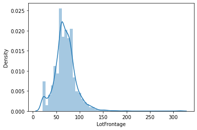

```python
sns.distplot(data['LotFrontage'][data['LotFrontage'].notnull()])
```

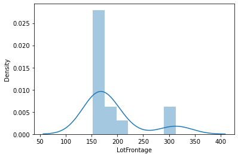

```python
sns.distplot(data['LotFrontage'][data['LotFrontage']>150])
```

```python
data['LotFrontage'].median()
```

```
68.0
```

```python
data['LotFrontage'] = data['LotFrontage'].fillna(data['LotFrontage'].median())
data['LotFrontage'].head(10)
```

```
0    65.0
1    80.0
2    68.0
3    60.0
4    84.0
5    85.0
6    75.0
7    68.0
8    51.0
9    50.0
Name: LotFrontage, dtype: float64
```

Toutes les valeurs manquantes relatives aux garages indiquent en réalité l'absence de garage

```python
data[['GarageType', 'GarageFinish', 'GarageQual', 'GarageCond','GarageYrBlt', 'GarageArea', 'GarageCars']].head(10)
```

|  | GarageType | GarageFinish | GarageQual | GarageCond | GarageYrBlt | GarageArea | GarageCars |
| --- | --- | --- | --- | --- | --- | --- | --- |
| 0 | Attchd | RFn | TA | TA | 2003.0 | 548.0 | 2.0 |
| 1 | Attchd | RFn | TA | TA | 1976.0 | 460.0 | 2.0 |
| 2 | Attchd | RFn | TA | TA | 2001.0 | 608.0 | 2.0 |
| 3 | Detchd | Unf | TA | TA | 1998.0 | 642.0 | 3.0 |
| 4 | Attchd | RFn | TA | TA | 2000.0 | 836.0 | 3.0 |
| 5 | Attchd | Unf | TA | TA | 1993.0 | 480.0 | 2.0 |
| 6 | Attchd | RFn | TA | TA | 2004.0 | 636.0 | 2.0 |
| 7 | Attchd | RFn | TA | TA | 1973.0 | 484.0 | 2.0 |
| 8 | Detchd | Unf | Fa | TA | 1931.0 | 468.0 | 2.0 |
| 9 | Attchd | RFn | Gd | TA | 1939.0 | 205.0 | 1.0 |

Pour les valeurs qualitatives nous allons placer 'None' pour toute information manquante.  
Pour les valeurs quantitatives nous allons placer '0' pour toute information manquante

```python
data[['GarageType', 'GarageFinish', 'GarageQual', 'GarageCond']] = data[['GarageType', 'GarageFinish', 'GarageQual', 'GarageCond']].fillna("None")
data[['GarageYrBlt', 'GarageArea', 'GarageCars']] = data[['GarageYrBlt', 'GarageArea', 'GarageCars']].fillna(0)
```

On continue ce travail sur toutes les variables suivantes

```python
data[['BsmtFinSF1', 'BsmtFinSF2', 'BsmtUnfSF','TotalBsmtSF', 'BsmtFullBath', 'BsmtHalfBath']] = data[['BsmtFinSF1', 'BsmtFinSF2', 'BsmtUnfSF','TotalBsmtSF', 'BsmtFullBath', 'BsmtHalfBath']].fillna(0)
data[['BsmtQual', 'BsmtCond', 'BsmtExposure', 'BsmtFinType1', 'BsmtFinType2']] = data[['BsmtQual', 'BsmtCond', 'BsmtExposure', 'BsmtFinType1', 'BsmtFinType2']].fillna("None")
data["MasVnrType"] = data["MasVnrType"].fillna("None")
data["MasVnrArea"] = data["MasVnrArea"].fillna(0)
data['MSZoning'] = data['MSZoning'].fillna(data['MSZoning'].mode()[0])
data = data.drop(['Utilities'], axis=1)
data["Functional"] = data["Functional"].fillna("Typ")
data['Electrical'] = data['Electrical'].fillna(data['Electrical'].mode()[0])
data['KitchenQual'] = data['KitchenQual'].fillna(data['KitchenQual'].mode()[0])
data['Exterior1st'] = data['Exterior1st'].fillna(data['Exterior1st'].mode()[0])
data['Exterior2nd'] = data['Exterior2nd'].fillna(data['Exterior2nd'].mode()[0])
data['SaleType'] = data['SaleType'].fillna(data['SaleType'].mode()[0])
data['MSSubClass'] = data['MSSubClass'].fillna("None")
```

Et on vérifie finalement si certaines valeurs sont encore manquantes

```python
data_na = (data.isnull().sum() / len(data)) * 100
data_na
```

```
index            0.0
1stFlrSF         0.0
2ndFlrSF         0.0
3SsnPorch        0.0
Alley            0.0
BedroomAbvGr     0.0
BldgType         0.0
BsmtCond         0.0
BsmtExposure     0.0
BsmtFinSF1       0.0
BsmtFinSF2       0.0
BsmtFinType1     0.0
BsmtFinType2     0.0
BsmtFullBath     0.0
BsmtHalfBath     0.0
BsmtQual         0.0
BsmtUnfSF        0.0
CentralAir       0.0
Condition1       0.0
Condition2       0.0
Electrical       0.0
EnclosedPorch    0.0
ExterCond        0.0
ExterQual        0.0
Exterior1st      0.0
Exterior2nd      0.0
Fence            0.0
FireplaceQu      0.0
Fireplaces       0.0
Foundation       0.0
FullBath         0.0
Functional       0.0
GarageArea       0.0
GarageCars       0.0
GarageCond       0.0
GarageFinish     0.0
GarageQual       0.0
GarageType       0.0
GarageYrBlt      0.0
GrLivArea        0.0
```

[output cut: 26 more lines]

```
PoolArea         0.0
PoolQC           0.0
RoofMatl         0.0
RoofStyle        0.0
SaleCondition    0.0
SaleType         0.0
ScreenPorch      0.0
Street           0.0
TotRmsAbvGrd     0.0
TotalBsmtSF      0.0
WoodDeckSF       0.0
YearBuilt        0.0
YearRemodAdd     0.0
YrSold           0.0
dtype: float64
```

Aller plus loin :https://towardsdatascience.com/handling-missing-values-in-machine-learning-part-1-dda69d4f88ca

**Est-ce que l'information contenue dans une des colonnes ne peut pas être correlée au prix de la maison ?**

```python
data['Id'].head(5)
```

```
0    1
1    2
2    3
3    4
4    5
Name: Id, dtype: int64
```

```python
data.drop(['Id'],axis=1, inplace=True)
```

**Est-ce que certaines informations numériques sont réellement numériques ?**

```python
data[['MSSubClass','OverallCond','YrSold','MoSold']].head(5)
```

|  | MSSubClass | OverallCond | YrSold | MoSold |
| --- | --- | --- | --- | --- |
| 0 | 60 | 5 | 2008 | 2 |
| 1 | 20 | 8 | 2007 | 5 |
| 2 | 60 | 5 | 2008 | 9 |
| 3 | 70 | 5 | 2006 | 2 |
| 4 | 60 | 5 | 2008 | 12 |

- MSSubClass: The building class
- OverallCond: Overall condition rating
- MoSold: Month Sold
- YrSold: Year Sold

```python
data[['MSSubClass','OverallCond','YrSold','MoSold']] = data[['MSSubClass','OverallCond','YrSold','MoSold']].astype('object')
data[['MSSubClass','OverallCond','YrSold','MoSold']].head(5)
```

|  | MSSubClass | OverallCond | YrSold | MoSold |
| --- | --- | --- | --- | --- |
| 0 | 60 | 5 | 2008 | 2 |
| 1 | 20 | 8 | 2007 | 5 |
| 2 | 60 | 5 | 2008 | 9 |
| 3 | 70 | 5 | 2006 | 2 |
| 4 | 60 | 5 | 2008 | 12 |

Est-ce qu'il n'est pas possible ici de faire du feature modeling ?

```python
data[['YearBuilt','YearRemodAdd']].head(5)
```

|  | YearBuilt | YearRemodAdd |
| --- | --- | --- |
| 0 | 2003 | 2003 |
| 1 | 1976 | 1976 |
| 2 | 2001 | 2002 |
| 3 | 1915 | 1970 |
| 4 | 2000 | 2000 |

```python
import datetime
current_date = datetime.datetime.now().year
current_date
```

```
2022
```

```python
data['years since last remod'] = current_date - data['YearRemodAdd']
data.drop(['YearBuilt','YearRemodAdd'], axis=1, inplace = True)
data['years since last remod'].head(3)
```

```
0    19
1    46
2    20
Name: years since last remod, dtype: int64
```

**Préparer ses datasets de test et d'entrainement**

```python
train.head(3)
```

|  | Id | MSSubClass | MSZoning | LotFrontage | LotArea | Street | Alley | LotShape | LandContour | Utilities | ... | PoolArea | PoolQC | Fence | MiscFeature | MiscVal | MoSold | YrSold | SaleType | SaleCondition | SalePrice |
| --- | --- | --- | --- | --- | --- | --- | --- | --- | --- | --- | --- | --- | --- | --- | --- | --- | --- | --- | --- | --- | --- |
| 0 | 1 | 60 | RL | 65.0 | 8450 | Pave | NaN | Reg | Lvl | AllPub | ... | 0 | NaN | NaN | NaN | 0 | 2 | 2008 | WD | Normal | 208500 |
| 1 | 2 | 20 | RL | 80.0 | 9600 | Pave | NaN | Reg | Lvl | AllPub | ... | 0 | NaN | NaN | NaN | 0 | 5 | 2007 | WD | Normal | 181500 |
| 2 | 3 | 60 | RL | 68.0 | 11250 | Pave | NaN | IR1 | Lvl | AllPub | ... | 0 | NaN | NaN | NaN | 0 | 9 | 2008 | WD | Normal | 223500 |

3 rows × 81 columns

```python
test.head(3)
```

|  | Id | MSSubClass | MSZoning | LotFrontage | LotArea | Street | Alley | LotShape | LandContour | Utilities | ... | ScreenPorch | PoolArea | PoolQC | Fence | MiscFeature | MiscVal | MoSold | YrSold | SaleType | SaleCondition |
| --- | --- | --- | --- | --- | --- | --- | --- | --- | --- | --- | --- | --- | --- | --- | --- | --- | --- | --- | --- | --- | --- |
| 0 | 1461 | 20 | RH | 80.0 | 11622 | Pave | NaN | Reg | Lvl | AllPub | ... | 120 | 0 | NaN | MnPrv | NaN | 0 | 6 | 2010 | WD | Normal |
| 1 | 1462 | 20 | RL | 81.0 | 14267 | Pave | NaN | IR1 | Lvl | AllPub | ... | 0 | 0 | NaN | NaN | Gar2 | 12500 | 6 | 2010 | WD | Normal |
| 2 | 1463 | 60 | RL | 74.0 | 13830 | Pave | NaN | IR1 | Lvl | AllPub | ... | 0 | 0 | NaN | MnPrv | NaN | 0 | 3 | 2010 | WD | Normal |

3 rows × 80 columns

```python
dataset = data.loc[:1459,:]
```

```python
pd.options.mode.chained_assignment = None
dataset['SalePrice'] = train['SalePrice']
```

```python
dataset.head(3)
```

|  | index | 1stFlrSF | 2ndFlrSF | 3SsnPorch | Alley | BedroomAbvGr | BldgType | BsmtCond | BsmtExposure | BsmtFinSF1 | ... | SaleCondition | SaleType | ScreenPorch | Street | TotRmsAbvGrd | TotalBsmtSF | WoodDeckSF | YrSold | years since last remod | SalePrice |
| --- | --- | --- | --- | --- | --- | --- | --- | --- | --- | --- | --- | --- | --- | --- | --- | --- | --- | --- | --- | --- | --- |
| 0 | 0 | 856 | 854 | 0 | None | 3 | 1Fam | TA | No | 706.0 | ... | Normal | WD | 0 | Pave | 8 | 856.0 | 0 | 2008 | 19 | 208500 |
| 1 | 1 | 1262 | 0 | 0 | None | 3 | 1Fam | TA | Gd | 978.0 | ... | Normal | WD | 0 | Pave | 6 | 1262.0 | 298 | 2007 | 46 | 181500 |
| 2 | 2 | 920 | 866 | 0 | None | 3 | 1Fam | TA | Mn | 486.0 | ... | Normal | WD | 0 | Pave | 6 | 920.0 | 0 | 2008 | 20 | 223500 |

3 rows × 79 columns

```python
dataset.drop(['index'],axis=1, inplace=True)
```

```python
import random
```

```python
random.seed(1)
random_indices = random.sample(range(0, len(dataset)),k=len(dataset))
datasetR = dataset.iloc[random_indices]
datasetR.head(5)
```

|  | 1stFlrSF | 2ndFlrSF | 3SsnPorch | Alley | BedroomAbvGr | BldgType | BsmtCond | BsmtExposure | BsmtFinSF1 | BsmtFinSF2 | ... | SaleCondition | SaleType | ScreenPorch | Street | TotRmsAbvGrd | TotalBsmtSF | WoodDeckSF | YrSold | years since last remod | SalePrice |
| --- | --- | --- | --- | --- | --- | --- | --- | --- | --- | --- | --- | --- | --- | --- | --- | --- | --- | --- | --- | --- | --- |
| 275 | 952 | 596 | 0 | None | 3 | 1Fam | TA | No | 0.0 | 0.0 | ... | Normal | WD | 144 | Pave | 5 | 952.0 | 74 | 2009 | 15 | 205000 |
| 1165 | 1502 | 0 | 0 | None | 3 | 1Fam | TA | No | 0.0 | 0.0 | ... | Partial | New | 0 | Pave | 7 | 1502.0 | 0 | 2009 | 13 | 233170 |
| 129 | 1053 | 0 | 180 | None | 3 | 1Fam | TA | No | 567.0 | 28.0 | ... | Abnorml | WD | 0 | Pave | 6 | 1008.0 | 0 | 2006 | 31 | 150000 |
| 522 | 1004 | 660 | 0 | None | 3 | 1Fam | TA | No | 399.0 | 0.0 | ... | Normal | WD | 0 | Pave | 7 | 1004.0 | 0 | 2006 | 72 | 159000 |
| 241 | 866 | 0 | 0 | None | 2 | 1Fam | TA | No | 329.0 | 0.0 | ... | Normal | WD | 0 | Pave | 4 | 686.0 | 58 | 2007 | 25 | 110500 |

5 rows × 78 columns

```python
datasetR.reset_index(inplace=True)
datasetR.drop(['index'],axis=1, inplace=True)
datasetR.head(5)
```

|  | 1stFlrSF | 2ndFlrSF | 3SsnPorch | Alley | BedroomAbvGr | BldgType | BsmtCond | BsmtExposure | BsmtFinSF1 | BsmtFinSF2 | ... | SaleCondition | SaleType | ScreenPorch | Street | TotRmsAbvGrd | TotalBsmtSF | WoodDeckSF | YrSold | years since last remod | SalePrice |
| --- | --- | --- | --- | --- | --- | --- | --- | --- | --- | --- | --- | --- | --- | --- | --- | --- | --- | --- | --- | --- | --- |
| 0 | 952 | 596 | 0 | None | 3 | 1Fam | TA | No | 0.0 | 0.0 | ... | Normal | WD | 144 | Pave | 5 | 952.0 | 74 | 2009 | 15 | 205000 |
| 1 | 1502 | 0 | 0 | None | 3 | 1Fam | TA | No | 0.0 | 0.0 | ... | Partial | New | 0 | Pave | 7 | 1502.0 | 0 | 2009 | 13 | 233170 |
| 2 | 1053 | 0 | 180 | None | 3 | 1Fam | TA | No | 567.0 | 28.0 | ... | Abnorml | WD | 0 | Pave | 6 | 1008.0 | 0 | 2006 | 31 | 150000 |
| 3 | 1004 | 660 | 0 | None | 3 | 1Fam | TA | No | 399.0 | 0.0 | ... | Normal | WD | 0 | Pave | 7 | 1004.0 | 0 | 2006 | 72 | 159000 |
| 4 | 866 | 0 | 0 | None | 2 | 1Fam | TA | No | 329.0 | 0.0 | ... | Normal | WD | 0 | Pave | 4 | 686.0 | 58 | 2007 | 25 | 110500 |

5 rows × 78 columns

```python
cut = round(len(datasetR)*0.8)
cut
```

```
1168
```

```python
dsTrain = datasetR.iloc[0:cut,:]
dsTest = datasetR.iloc[cut:,:]
```

**Créer son premier modèle de prédiction avec une regression univariée**

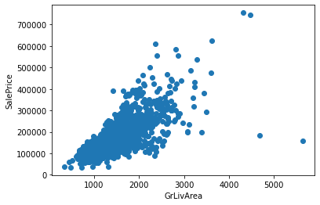

```python
fig, ax = plt.subplots()
ax.scatter(x = datasetR['GrLivArea'], y = datasetR['SalePrice'])
plt.ylabel('SalePrice')
plt.xlabel('GrLivArea')
plt.show()
```

```python
from sklearn import linear_model
from sklearn.metrics import mean_squared_error

lr = linear_model.LinearRegression() #quel type de modèle je souhaite utiliser ?

lr.fit(dsTrain[['GrLivArea']],dsTrain['SalePrice']) # entrainement du modèle

prediction = lr.predict(dsTest[['GrLivArea']]) # réaliser la prédiction
prediction[0:5]
```

```
array([136846.02292284, 141626.33087422, 207355.56520564, 167021.7168659 ,
       135949.71518196])
```

```python
rmse = mean_squared_error(prediction,dsTest['SalePrice'])**(1/2) # calculer l'erreur
rmse
```

```
61735.123131297274
```

```python
def linearRegression(datasetR,fit,toPredict):

    cut = round(len(datasetR)*0.8)
    dsTrain = datasetR.iloc[0:cut,:].reset_index()
    dsTest = datasetR.iloc[cut:,:]

    lr = linear_model.LinearRegression()
    lr.fit(dsTrain[fit],dsTrain[toPredict])
    prediction = lr.predict(dsTest[fit])
    rmse = mean_squared_error(prediction,dsTest[toPredict])**(1/2)
    return rmse

linearRegression(datasetR,['GrLivArea'],'SalePrice')
```

```
61735.123131297274
```

**Standardisation des valeurs**

```python
datasetR.select_dtypes(include=['int64','float64']).head(3)
```

|  | 1stFlrSF | 2ndFlrSF | 3SsnPorch | BedroomAbvGr | BsmtFinSF1 | BsmtFinSF2 | BsmtFullBath | BsmtHalfBath | BsmtUnfSF | EnclosedPorch | ... | MiscVal | OpenPorchSF | OverallQual | PoolArea | ScreenPorch | TotRmsAbvGrd | TotalBsmtSF | WoodDeckSF | years since last remod | SalePrice |
| --- | --- | --- | --- | --- | --- | --- | --- | --- | --- | --- | --- | --- | --- | --- | --- | --- | --- | --- | --- | --- | --- |
| 0 | 952 | 596 | 0 | 3 | 0.0 | 0.0 | 0.0 | 0.0 | 952.0 | 0 | ... | 0 | 0 | 7 | 0 | 144 | 5 | 952.0 | 74 | 15 | 205000 |
| 1 | 1502 | 0 | 0 | 3 | 0.0 | 0.0 | 0.0 | 0.0 | 1502.0 | 0 | ... | 0 | 114 | 7 | 0 | 0 | 7 | 1502.0 | 0 | 13 | 233170 |
| 2 | 1053 | 0 | 180 | 3 | 567.0 | 28.0 | 0.0 | 1.0 | 413.0 | 0 | ... | 0 | 80 | 5 | 0 | 0 | 6 | 1008.0 | 0 | 31 | 150000 |

3 rows × 32 columns

```python
fullListNumbersAndPrice = list(datasetR.select_dtypes(include=['int64','float64']).columns)
#print(fullListNumbersAndPrice)

fullListNumbers = fullListNumbersAndPrice[:-1]
print(fullListNumbers)
```

```
['1stFlrSF', '2ndFlrSF', '3SsnPorch', 'BedroomAbvGr', 'BsmtFinSF1', 'BsmtFinSF2', 'BsmtFullBath', 'BsmtHalfBath', 'BsmtUnfSF', 'EnclosedPorch', 'Fireplaces', 'FullBath', 'GarageArea', 'GarageCars', 'GarageYrBlt', 'GrLivArea', 'HalfBath', 'KitchenAbvGr', 'LotArea', 'LotFrontage', 'LowQualFinSF', 'Mas…
```

```python
from sklearn import preprocessing
scaler = preprocessing.StandardScaler()
dfStand = scaler.fit_transform(datasetR[fullListNumbers])
dfStand = pd.DataFrame(dfStand, columns=fullListNumbers)
dfStand.head(5)
```

|  | 1stFlrSF | 2ndFlrSF | 3SsnPorch | BedroomAbvGr | BsmtFinSF1 | BsmtFinSF2 | BsmtFullBath | BsmtHalfBath | BsmtUnfSF | EnclosedPorch | ... | MasVnrArea | MiscVal | OpenPorchSF | OverallQual | PoolArea | ScreenPorch | TotRmsAbvGrd | TotalBsmtSF | WoodDeckSF | years since last remod |
| --- | --- | --- | --- | --- | --- | --- | --- | --- | --- | --- | --- | --- | --- | --- | --- | --- | --- | --- | --- | --- | --- |
| 0 | -0.545022 | 0.570622 | -0.116339 | 0.163779 | -0.973018 | -0.288653 | -0.819964 | -0.241061 | 0.871057 | -0.359325 | ... | -0.570750 | -0.087688 | -0.704483 | 0.651479 | -0.068692 | 2.313293 | -0.934130 | -0.240402 | -0.161574 | -1.072482 |
| 1 | 0.878170 | -0.795163 | -0.116339 | 0.163779 | -0.973018 | -0.288653 | -0.819964 | -0.241061 | 2.116202 | -0.359325 | ... | 0.912622 | -0.087688 | 1.016704 | 0.651479 | -0.068692 | -0.270208 | 0.296763 | 1.013717 | -0.752176 | -1.169389 |
| 2 | -0.283672 | -0.795163 | 6.025478 | 0.163779 | 0.270561 | -0.115025 | -0.819964 | 3.948809 | -0.349185 | -0.359325 | ... | -0.100278 | -0.087688 | 0.503368 | -0.795151 | -0.068692 | -0.270208 | -0.318683 | -0.112710 | -0.752176 | -0.297226 |
| 3 | -0.410466 | 0.717284 | -0.116339 | 0.163779 | -0.097907 | -0.288653 | -0.819964 | -0.241061 | 0.085484 | 0.229890 | ... | -0.570750 | -0.087688 | -0.342128 | -0.071836 | -0.068692 | -0.270208 | 0.296763 | -0.121831 | -0.752176 | 1.689368 |
| 4 | -0.767558 | -0.795163 | -0.116339 | -1.062465 | -0.251435 | -0.288653 | -0.819964 | -0.241061 | -0.475963 | -0.359325 | ... | -0.570750 | -0.087688 | -0.070361 | -0.795151 | -0.068692 | -0.270208 | -1.549576 | -0.846939 | -0.289271 | -0.587947 |

5 rows × 31 columns

```python
def linearRegression(datasetR,fit,toPredict):
    fullListNumbers = list(datasetR.select_dtypes(include=['int64','float64']).columns)
    fullListNumbers = fullListNumbers[:-1]

    scaler = preprocessing.StandardScaler()
    dfStand = scaler.fit_transform(datasetR[fullListNumbers])
    dfStand = pd.DataFrame(dfStand, columns=fullListNumbers)
    datasetR[fullListNumbers] = dfStand

    cut = round(len(datasetR)*0.8)
    dsTrain = datasetR.iloc[0:cut,:].reset_index()
    dsTest = datasetR.iloc[cut:,:]

    lr = linear_model.LinearRegression()
    lr.fit(dsTrain[fit],dsTrain[toPredict])
    prediction = lr.predict(dsTest[fit])
    rmse = mean_squared_error(prediction,dsTest[toPredict])**(1/2)
    return rmse

linearRegression(datasetR,['GrLivArea'],'SalePrice')
```

```
61735.123131297274
```

**Regression linéaire avec plusieurs colonnes d'entrainement**

```python
datasetR['GarageCars'].head(10)
```

```
0    0.311725
1    0.311725
2    0.311725
3    0.311725
4   -2.365440
5   -1.026858
6    0.311725
7   -1.026858
8    0.311725
9    0.311725
Name: GarageCars, dtype: float64
```

```python
fit = ['GrLivArea','GarageCars']
linearRegression(datasetR,fit,'SalePrice')
```

```
54726.25291419831
```

Youhou ! on a plus qu'à ajouter toutes les colonnes !

```python
results = []
for i in range(len(fullListNumbers)):
    fit = fullListNumbers[0:i+1]
    result = linearRegression(datasetR,fit,'SalePrice')
    results.append(result)
```

```
40028.85180871347
```

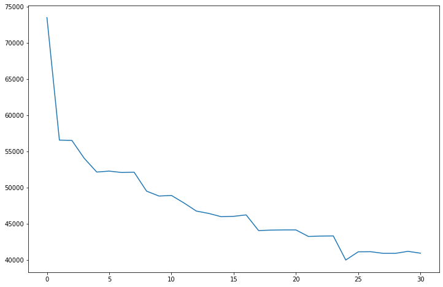

```python
import numpy as np
print(min(results))
plt.figure(figsize=(12, 8))
sns.lineplot(y=results, x=list(np.arange(0,len(fullListNumbers))))
plt.show()
```

**Faire le tri parmi les features numériques**

Ecarter les colonnes avec une corrélation faible avec le prix

```python
datasetR[fullListNumbersAndPrice].corr().head(5)
```

|  | 1stFlrSF | 2ndFlrSF | 3SsnPorch | BedroomAbvGr | BsmtFinSF1 | BsmtFinSF2 | BsmtFullBath | BsmtHalfBath | BsmtUnfSF | EnclosedPorch | ... | MiscVal | OpenPorchSF | OverallQual | PoolArea | ScreenPorch | TotRmsAbvGrd | TotalBsmtSF | WoodDeckSF | years since last remod | SalePrice |
| --- | --- | --- | --- | --- | --- | --- | --- | --- | --- | --- | --- | --- | --- | --- | --- | --- | --- | --- | --- | --- | --- |
| 1stFlrSF | 1.000000 | -0.202646 | 0.056104 | 0.127401 | 0.445863 | 0.097117 | 0.244671 | 0.001956 | 0.317987 | -0.065292 | ... | -0.021096 | 0.211671 | 0.476224 | 0.131525 | 0.088758 | 0.409516 | 0.819530 | 0.235459 | -0.240379 | 0.605852 |
| 2ndFlrSF | -0.202646 | 1.000000 | -0.024358 | 0.502901 | -0.137079 | -0.099260 | -0.169494 | -0.023855 | 0.004469 | 0.061989 | ... | 0.016197 | 0.208026 | 0.295493 | 0.081487 | 0.040606 | 0.616423 | -0.174512 | 0.092165 | -0.140024 | 0.319334 |
| 3SsnPorch | 0.056104 | -0.024358 | 1.000000 | -0.024478 | 0.026451 | -0.029993 | -0.000106 | 0.035114 | 0.020764 | -0.037305 | ... | 0.000354 | -0.005842 | 0.030371 | -0.007992 | -0.031436 | -0.006683 | 0.037384 | -0.032771 | -0.045286 | 0.044584 |
| BedroomAbvGr | 0.127401 | 0.502901 | -0.024478 | 1.000000 | -0.107355 | -0.015728 | -0.150673 | 0.046519 | 0.166643 | 0.041570 | ... | 0.007767 | 0.093810 | 0.101676 | 0.070703 | 0.044300 | 0.676620 | 0.050450 | 0.046854 | 0.040581 | 0.168213 |
| BsmtFinSF1 | 0.445863 | -0.137079 | 0.026451 | -0.107355 | 1.000000 | -0.050117 | 0.649212 | 0.067418 | -0.495251 | -0.102303 | ... | 0.003571 | 0.111761 | 0.239666 | 0.140491 | 0.062021 | 0.044316 | 0.522396 | 0.204306 | -0.128451 | 0.386420 |

5 rows × 32 columns

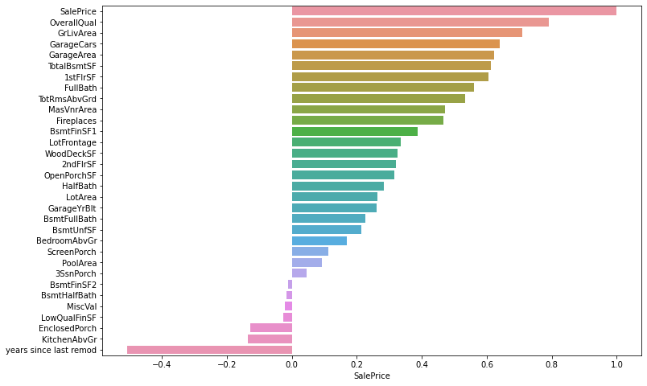

```python
df_corr = datasetR[fullListNumbersAndPrice].corr()
corrSalesprice = df_corr.sort_values('SalePrice',ascending=False)
plt.figure(figsize=(12, 8))
sns.barplot(x=corrSalesprice['SalePrice'], y=corrSalesprice.index)
plt.show()
```

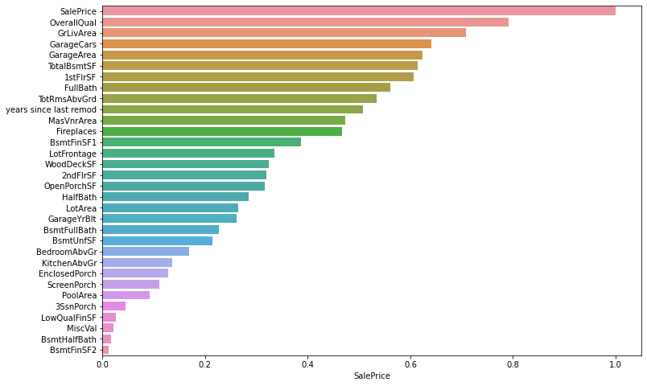

```python
df_corr = abs(datasetR[fullListNumbersAndPrice].corr())
corrSalesprice = df_corr.sort_values('SalePrice',ascending=False)

plt.figure(figsize=(12, 8))
sns.barplot(x=corrSalesprice['SalePrice'], y=corrSalesprice.index)
plt.show()
```

0.00-0.19: very weak  
0.20-0.39: weak  
0.40-0.59: moderate  
0.60-0.79: strong  
0.80-1.00: very strong.

```python
less20Percent = list(corrSalesprice[corrSalesprice['SalePrice'] > 0.2].index)
less20Percent.remove('SalePrice')
print(less20Percent)

less40Percent = list(corrSalesprice[corrSalesprice['SalePrice'] > 0.4].index)
less40Percent.remove('SalePrice')
print(less40Percent)
```

```
['OverallQual', 'GrLivArea', 'GarageCars', 'GarageArea', 'TotalBsmtSF', '1stFlrSF', 'FullBath', 'TotRmsAbvGrd', 'years since last remod', 'MasVnrArea', 'Fireplaces', 'BsmtFinSF1', 'LotFrontage', 'WoodDeckSF', '2ndFlrSF', 'OpenPorchSF', 'HalfBath', 'LotArea', 'GarageYrBlt', 'BsmtFullBath', 'BsmtUnfSF…
['OverallQual', 'GrLivArea', 'GarageCars', 'GarageArea', 'TotalBsmtSF', '1stFlrSF', 'FullBath', 'TotRmsAbvGrd', 'years since last remod', 'MasVnrArea', 'Fireplaces']
```

```python
print(linearRegression(datasetR,fullListNumbers,'SalePrice'))
print(linearRegression(datasetR,less20Percent,'SalePrice')) #Winner !
print(linearRegression(datasetR,less40Percent,'SalePrice'))
```

```
40972.81035526955
40841.44639434629
42933.790065642635
```

Supprimer les colonnes trop similaires

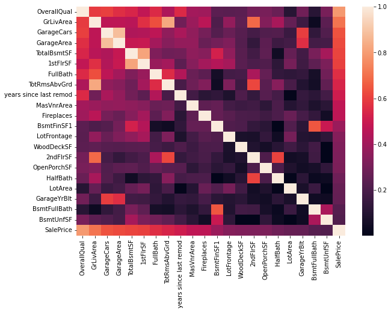

```python
less20Percent.append('SalePrice')
fullListNumbers = less20Percent
df_corr = abs(datasetR[fullListNumbers].corr())
plt.figure(figsize=(10, 7))
sns.heatmap(df_corr)
plt.show()
```

On voit que certaines caractéristiques semblent liés :

- Total bsmt SF (Total square feet of basement area) et 1st Flr SF (First Floor square feet)
- Gr Liv Area (Above grade (ground) living area square feet) et TotRms AbvGrd (Total rooms above grade (does not include bathrooms)
- Garage cars (Size of garage in car capacity) et garage Area (Garage Area)

```python
fullListNumbers.remove('1stFlrSF')
fullListNumbers.remove('TotRmsAbvGrd')
fullListNumbers.remove('GarageCars')
#'2ndFlrSF'
print(fullListNumbers)
```

```
['OverallQual', 'GrLivArea', 'GarageArea', 'TotalBsmtSF', 'FullBath', 'years since last remod', 'MasVnrArea', 'Fireplaces', 'BsmtFinSF1', 'LotFrontage', 'WoodDeckSF', '2ndFlrSF', 'OpenPorchSF', 'HalfBath', 'LotArea', 'GarageYrBlt', 'BsmtFullBath', 'BsmtUnfSF', 'SalePrice']
```

```python
fullListNumbers.remove('SalePrice')
linearRegression(datasetR,fullListNumbers,'SalePrice')
```

```
40714.49891248938
```

**Intégration des valeurs catégoricielles**

```python
allcatColumns = list(datasetR.select_dtypes(include=['object']).columns)
print(allcatColumns)
```

```
['Alley', 'BldgType', 'BsmtCond', 'BsmtExposure', 'BsmtFinType1', 'BsmtFinType2', 'BsmtQual', 'CentralAir', 'Condition1', 'Condition2', 'Electrical', 'ExterCond', 'ExterQual', 'Exterior1st', 'Exterior2nd', 'Fence', 'FireplaceQu', 'Foundation', 'Functional', 'GarageCond', 'GarageFinish', 'GarageQual'…
```

```
Alley - nombre de catégories : 3 - Pourcentage de la valeur 1 : 0.9376712328767123
```

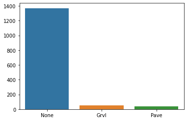

```python
test = datasetR.groupby(datasetR['Alley']).size().sort_values(ascending=False)
sns.barplot(x=list(test.index), y=list(test.iloc[0:]))
print('Alley' + ' - nombre de catégories : ' + str(len(test)) + ' - Pourcentage de la valeur 1 : ' + str(test[0]/len(datasetR)))
```

Nous trions mainteant parmis les données catégoricielles. Il faut d'abord retirer celles ne variant pas assez ou ayant trop de valeurs différentes.

```python
for i in allcatColumns:
    test = datasetR.groupby(datasetR[i]).size().sort_values(ascending=False)
    print(i + ' - nombre de catégories : ' + str(len(test)) + ' - Pourcentage de la valeur 1 : '+ str(test.iloc[0]/len(datasetR)))
```

```
Alley - nombre de catégories : 3 - Pourcentage de la valeur 1 : 0.9376712328767123
BldgType - nombre de catégories : 5 - Pourcentage de la valeur 1 : 0.8356164383561644
BsmtCond - nombre de catégories : 5 - Pourcentage de la valeur 1 : 0.897945205479452
BsmtExposure - nombre de catégories : 5 - Pourcentage de la valeur 1 : 0.6527397260273973
BsmtFinType1 - nombre de catégories : 7 - Pourcentage de la valeur 1 : 0.2945205479452055
BsmtFinType2 - nombre de catégories : 7 - Pourcentage de la valeur 1 : 0.8602739726027397
BsmtQual - nombre de catégories : 5 - Pourcentage de la valeur 1 : 0.44452054794520546
CentralAir - nombre de catégories : 2 - Pourcentage de la valeur 1 : 0.934931506849315
Condition1 - nombre de catégories : 9 - Pourcentage de la valeur 1 : 0.863013698630137
Condition2 - nombre de catégories : 8 - Pourcentage de la valeur 1 : 0.9897260273972602
Electrical - nombre de catégories : 5 - Pourcentage de la valeur 1 : 0.9143835616438356
ExterCond - nombre de catégories : 5 - Pourcentage de la valeur 1 : 0.8780821917808219
ExterQual - nombre de catégories : 4 - Pourcentage de la valeur 1 : 0.6205479452054794
Exterior1st - nombre de catégories : 15 - Pourcentage de la valeur 1 : 0.3527397260273973
Exterior2nd - nombre de catégories : 16 - Pourcentage de la valeur 1 : 0.3452054794520548
Fence - nombre de catégories : 5 - Pourcentage de la valeur 1 : 0.8075342465753425
FireplaceQu - nombre de catégories : 6 - Pourcentage de la valeur 1 : 0.4726027397260274
Foundation - nombre de catégories : 6 - Pourcentage de la valeur 1 : 0.44315068493150683
Functional - nombre de catégories : 7 - Pourcentage de la valeur 1 : 0.9315068493150684
GarageCond - nombre de catégories : 6 - Pourcentage de la valeur 1 : 0.9082191780821918
GarageFinish - nombre de catégories : 4 - Pourcentage de la valeur 1 : 0.4143835616438356
GarageQual - nombre de catégories : 6 - Pourcentage de la valeur 1 : 0.897945205479452
GarageType - nombre de catégories : 7 - Pourcentage de la valeur 1 : 0.5958904109589042
Heating - nombre de catégories : 6 - Pourcentage de la valeur 1 : 0.9780821917808219
HeatingQC - nombre de catégories : 5 - Pourcentage de la valeur 1 : 0.5075342465753425
HouseStyle - nombre de catégories : 8 - Pourcentage de la valeur 1 : 0.49726027397260275
KitchenQual - nombre de catégories : 4 - Pourcentage de la valeur 1 : 0.5034246575342466
LandContour - nombre de catégories : 4 - Pourcentage de la valeur 1 : 0.897945205479452
LandSlope - nombre de catégories : 3 - Pourcentage de la valeur 1 : 0.9465753424657535
LotConfig - nombre de catégories : 5 - Pourcentage de la valeur 1 : 0.7205479452054795
LotShape - nombre de catégories : 4 - Pourcentage de la valeur 1 : 0.6335616438356164
MSSubClass - nombre de catégories : 15 - Pourcentage de la valeur 1 : 0.36712328767123287
MSZoning - nombre de catégories : 5 - Pourcentage de la valeur 1 : 0.7883561643835616
MasVnrType - nombre de catégories : 4 - Pourcentage de la valeur 1 : 0.5972602739726027
MiscFeature - nombre de catégories : 5 - Pourcentage de la valeur 1 : 0.963013698630137
MoSold - nombre de catégories : 12 - Pourcentage de la valeur 1 : 0.17328767123287672
Neighborhood - nombre de catégories : 25 - Pourcentage de la valeur 1 : 0.1541095890410959
OverallCond - nombre de catégories : 9 - Pourcentage de la valeur 1 : 0.5623287671232877
PavedDrive - nombre de catégories : 3 - Pourcentage de la valeur 1 : 0.9178082191780822
PoolQC - nombre de catégories : 4 - Pourcentage de la valeur 1 : 0.9952054794520548
RoofMatl - nombre de catégories : 8 - Pourcentage de la valeur 1 : 0.9821917808219178
RoofStyle - nombre de catégories : 6 - Pourcentage de la valeur 1 : 0.7815068493150685
SaleCondition - nombre de catégories : 6 - Pourcentage de la valeur 1 : 0.8205479452054795
SaleType - nombre de catégories : 9 - Pourcentage de la valeur 1 : 0.8678082191780822
Street - nombre de catégories : 2 - Pourcentage de la valeur 1 : 0.9958904109589041
YrSold - nombre de catégories : 5 - Pourcentage de la valeur 1 : 0.23150684931506849
```

Parce qu'une même valeur est rencontrée dans plus de 80% des cas, ou un nombre de catégories trop importantes est constatée nous supprimons ces élements : Alley,BldgType,BsmtCond,BsmtFinType2,CentralAir,Condition1,Condition2,Electrical,ExterCond,Exterior1st,Exterior2nd,Fence, Functional,GarageCond,GarageQual,Heating,LandContour,LandSlope,MSSubClass,MiscFeature,MoSold,Neighborhood,PavedDrive,PoolQC, RoofMatl,SaleCondition,SaleType,Street

```python
toDelete = ['Alley','BldgType','BsmtCond','BsmtFinType2','CentralAir','Condition1','Condition2','Electrical','ExterCond','Exterior1st','Exterior2nd','Fence','Functional','GarageCond','GarageQual','Heating','LandContour','LandSlope','MSSubClass','MiscFeature','MoSold','Neighborhood','PavedDrive','PoolQC','RoofMatl','SaleCondition','SaleType','Street']
for i in toDelete:
    allcatColumns.remove(i)

print(allcatColumns)
```

```
['BsmtExposure', 'BsmtFinType1', 'BsmtQual', 'ExterQual', 'FireplaceQu', 'Foundation', 'GarageFinish', 'GarageType', 'HeatingQC', 'HouseStyle', 'KitchenQual', 'LotConfig', 'LotShape', 'MSZoning', 'MasVnrType', 'OverallCond', 'RoofStyle', 'YrSold']
```

```python
def linearRegression(datasetR,fit,toPredict):
    fullListNumbers = list(datasetR.select_dtypes(include=['int64','float64']).columns)
    fullListNumbers = fullListNumbers[:-1]

    scaler = preprocessing.StandardScaler()
    dfStand = scaler.fit_transform(datasetR[fullListNumbers])
    dfStand = pd.DataFrame(dfStand, columns=fullListNumbers)
    datasetR[fullListNumbers] = dfStand

    allcatColumns = list(datasetR[fit].select_dtypes(include=['object']).columns)
    dummy_cols = pd.DataFrame()
    for col in allcatColumns:
        col_dummies = pd.get_dummies(datasetR[col],prefix=str(col))
        datasetR = pd.concat([datasetR, col_dummies], axis=1)
        del datasetR[col]
        fit = fit + list(col_dummies.columns)
        fit.remove(col)

    cut = round(len(datasetR)*0.8)
    dsTrain = datasetR.iloc[0:cut,:]
    dsTest = datasetR.iloc[cut:,:]

    lr = linear_model.LinearRegression()
    lr.fit(dsTrain[fit],dsTrain[toPredict])
    prediction = lr.predict(dsTest[fit])
    rmse = mean_squared_error(prediction,dsTest[toPredict])**(1/2)
    return rmse

fullcolumnslist =  fullListNumbers + allcatColumns
```

```python
fullcolumnslist =  fullListNumbers + allcatColumns

result = linearRegression(datasetR,['OverallQual'],'SalePrice')

newcolumns = ['OverallQual']
for i in range(len(fullcolumnslist)):
    fit = fullcolumnslist[0:i+1]
    test = linearRegression(datasetR,fit,'SalePrice')
    if test < result:
        newcolumns.append(fullcolumnslist[i])
        result = test

print(newcolumns)
```

```
['OverallQual', 'GrLivArea', 'GarageArea', 'TotalBsmtSF', 'years since last remod', 'MasVnrArea', 'BsmtFinSF1', 'LotFrontage', 'LotArea', 'GarageYrBlt', 'BsmtFullBath', 'BsmtUnfSF', 'BsmtExposure', 'BsmtQual', 'ExterQual']
```

```python
linearRegression(datasetR,newcolumns,'SalePrice')
```

```
36643.81052276528
```

A vous ! Adaptez la fonction pour tester votre modèle sur le jeu de données d'entrainement du concours !

```python
datasetR[fullcolumnslist]
```

|  | OverallQual | GrLivArea | GarageArea | TotalBsmtSF | FullBath | years since last remod | MasVnrArea | Fireplaces | BsmtFinSF1 | LotFrontage | ... | HeatingQC | HouseStyle | KitchenQual | LotConfig | LotShape | MSZoning | MasVnrType | OverallCond | RoofStyle | YrSold |
| --- | --- | --- | --- | --- | --- | --- | --- | --- | --- | --- | --- | --- | --- | --- | --- | --- | --- | --- | --- | --- | --- |
| 0 | 0.651479 | 0.061938 | 0.931167 | -0.240402 | 0.789741 | -1.072482 | -0.570750 | -0.951226 | -0.973018 | -0.666638 | ... | Gd | 1.5Fin | Ex | Inside | Reg | RL | None | 7 | Gable | 2009 |
| 1 | 0.651479 | -0.025630 | 0.800162 | 1.013717 | 0.789741 | -1.169389 | 0.912622 | -0.951226 | -0.973018 | 0.422766 | ... | Ex | 1Story | Gd | Inside | IR1 | RL | Stone | 5 | Gable | 2009 |
| 2 | -0.795151 | -0.880380 | 1.296111 | -0.112710 | -1.026041 | -0.297226 | -0.100278 | -0.951226 | 0.270561 | -0.031152 | ... | TA | 1Story | Ex | Inside | Reg | RL | BrkFace | 7 | Gable | 2006 |
| 3 | -0.071836 | 0.282764 | -0.247882 | -0.121831 | 0.789741 | 1.689368 | -0.570750 | 2.152216 | -0.097907 | -0.893597 | ... | Ex | 1.5Fin | TA | Corner | Reg | RM | None | 7 | Gable | 2006 |
| 4 | -0.795151 | -1.236366 | -2.212963 | -0.846939 | -1.026041 | -0.587947 | -0.570750 | -0.951226 | -0.251435 | -1.347515 | ... | Gd | 1Story | Gd | Inside | Reg | RM | None | 9 | Gable | 2007 |
| ... | ... | ... | ... | ... | ... | ... | ... | ... | ... | ... | ... | ... | ... | ... | ... | ... | ... | ... | ... | ... | ... |
| 1455 | 1.374795 | 0.431251 | 0.425861 | 1.560968 | 0.789741 | -0.006505 | -0.570750 | 0.600495 | 1.544847 | -0.076544 | ... | TA | 1Story | Gd | CulDSac | IR1 | RL | None | 5 | Gable | 2006 |
| 1456 | -0.795151 | -0.769966 | -1.277210 | -1.006554 | -1.026041 | 1.689368 | -0.570750 | -0.951226 | -0.455408 | -0.439679 | ... | TA | 1.5Fin | TA | Inside | Reg | RL | None | 6 | Gable | 2008 |
| 1457 | -0.071836 | -0.292145 | -0.060731 | 0.694486 | 0.789741 | -1.024029 | 0.846202 | 0.600495 | -0.929153 | -0.394287 | ... | Ex | 1Story | Gd | Corner | IR1 | RL | Stone | 5 | Gable | 2007 |
| 1458 | -0.795151 | -0.501549 | 0.482006 | -1.261938 | -1.026041 | -0.297226 | -0.570750 | -0.951226 | -0.973018 | 1.012859 | ... | Gd | 1.5Fin | TA | Inside | IR1 | RL | None | 8 | Gable | 2006 |
| 1459 | -0.795151 | -0.886091 | -0.631540 | -0.016941 | -1.026041 | 1.398647 | -0.570750 | -0.951226 | 0.132386 | 0.468158 | ... | Gd | 1Story | TA | Inside | Reg | RL | None | 6 | Hip | 2009 |

1460 rows × 36 columns